# Food Industry During the Pandemic

JSC370 Midterm Report

Shih-Ting (Cindy) Huang

03/10/2022

## Introduction

After the emergence of COVID-19 in early 2020, undoubtedly many businesses were forced to close temporarily or permanently. Throughout this time, restaurants in particular have undergone various modifications, such as disabling dine-in, starting takeout, etc. As a result, the food quality, service quality, and overall dining experience might have changed - whether in a positive or negative way.

With that in mind, I propose the research question: How has COVID-19 affected restaurant performance and impression? Specifically, do restaurants with services that better comply with COVID restrictions necessarily have better reviews?

In order to answer this question, I utilized data from Yelp, one of the biggest platforms that displays information of businesses and enable users to search for, react to, and/or share their opinions of such businesses. Their data come from a total of 6,990,280 reviews and 150,346 businesses from 11 metropolitan areas - Montreal, Calgary, Toronto, Pittsburgh, Charlotte, Urbana-Champaign, Phoenix, Las Vegas, Madison, and Cleveland. Only reviews that are [recommended](https://www.yelp-support.com/Recommended_Reviews) by Yelp are included. For privacy reasons, contents of the dataset will not be disclosed.

## Methods

### Data Access

The data were retrieved directly from [Yelp’s Open Dataset](https://www.yelp.com/dataset) in a `.tar` compressed file. Extracting the respective json files and converting each to csv using Python, we selected two relevant datasets - `business` and `review`, which provides details on a business and a review respectively. Since we are observing the impact of COVID-19, we decided to only take reviews from the most recent five years (starting at 2017/01/01) and limit data size.

First, we take a look at what variables are present in each dataset. For `business`, we have:

Yelp Business Variable Definitions, obtained and modified from Yelp Dataset Documentation

| Variable Name | Definition |
| --- | --- |
| business_id | 22 character unique string business ID (str) |
| name | Business’s name (str) |
| address | Full address of the business (str) |
| city | City (str) |
| state | 2 character state code, if applicable (str) |
| postal_code | Postal code (str) |
| latitude | Latitude (dbl) |
| longitude | Longitude (dbl) |
| stars | Star rating from 0.0-5.0, rounded to half-stars (int) |
| review_count | Number of reviews (int) |
| is_open | Binary indicator for if business is open (=1) or closed (=0) (int) |
| attributes | A list of features associated with the business and whether it is available (True) or unavailable (False) (dict[str][bool]) |
| categories | Categories that the business belongs to (str) |
| hours | Business operating hours on a 24-hr clock (str[dict]) |

Next, we take a look at the `review` dataset:

Yelp Review Variable Definitions, obtained and modified from Yelp Dataset Documentation

| Variable Name | Definition |
| --- | --- |
| review_id | 22 character unique review id (str) |
| user_id | 22 character unique user id (str) |
| business_id | 22 character business id, maps to those in business dataset (str) |
| stars | Star rating (int) |
| date | Date formatted YYYY-MM-DD (str) |

### Data Wrangling

In order to better utilize the data for our research question, we will seek to wrangle the data as necessary.

#### Filtering Observations

Since we are only focusing on restaurant performance, we eliminated non-restaurant business in the `business` dataset and their corresponding reviews, retaining only those that are under the categories “Restaurants” or “Food”. The list of categories that Yelp offers can be found [here](https://blog.yelp.com/businesses/yelp_category_list/).

Originally, we have 150346 businesses and 3838105 reviews, and after filter we reduced to 21057 food businesses with 946469 reviews total.

#### Ensure validity of data in each observation

Checking potential problems with the data types, we verify that there are 20 problems total, all of which arise from variable `postal_code` with the value "".

#### Checking for NAs

As previously determined, we notice that the datasets represent missing values as an empty string "“, and below we showcase how many there are for each variable after converting”" to take on value `NA`:

Summary of NA Proportion for All Variables (Yelp Business)

|  | Proportion |
| --- | --- |
| business_id | 0.0000000 |
| name | 0.0000000 |
| address | 0.0190435 |
| city | 0.0000000 |
| state | 0.0000000 |
| postal_code | 0.0009498 |
| latitude | 0.0000000 |
| longitude | 0.0000000 |
| stars | 0.0000000 |
| review_count | 0.0000000 |
| is_open | 0.0000000 |
| attributes | 0.0094980 |
| categories | 0.0000000 |
| hours | 0.1005841 |

Summary of NA Proportion for All Variables (Yelp Reviews)

|  | Proportion |
| --- | --- |
| V1 | 0 |
| review_id | 0 |
| user_id | 0 |
| business_id | 0 |
| stars | 0 |
| date | 0 |

### Feature Engineering

In order to extract more information from our dataset, we will generated additional features from existing ones that may be helpful for our data exploration and analysis.

First, we try to identify businesses that opened before and after COVID-19. For the purpose of this research, we define the start of the pandemic as January 9th, 2020, which is when WHO reported globally that there has been a [new coronavirus identified](https://www.who.int/emergencies/diseases/novel-coronavirus-2019/interactive-timeline#event-7).

We then add a couple of other variables by extracting information from `attributes` and `hours`, which are dictionaries of restaurant features and open hours respectively. For indicator variables, we assigned the value 2 for unknown because the lack of such information could reveal insights about the restaurant performance as well. At this point, all of the variables we have added are:

- `pre_covid`: indicator for if restaurant did (=1) or did not open (=0) before COVID-19, or unknown (=2) based on their first review (int)
- `avg_hours`: the daily average open hours (float)
- `takeout`: indicator for if restaurant does (=1) or does not offer (=0) takeout, or unknown (=2) (int)
- `delivery`: indicator for if restaurant does (=1) or does not offer (=0) delivery, or unknown (=2) (int)
- `takeout_deli`: categorical for if restaurant offers takeout, delivery, both, or neither (chr)
- `good_for_groups`: indicator for if restaurant is (=1) or is not (=0) good for groups, or unknown (=2) (int)
- `outdoors`: indicator for if restaurant does (=1) or does not offer (=0) outdoor seating, or unknown (=2) (int)
- `price_range`: restaurant price range from 1-4 (int)

In addition to these variables, I would also like to engineer features related to each business’s categories on Yelp (ex. Fast Food, Cafe, Bar, etc.) and find a strategy to compare reviews before and after COVID.

### Tools used

Data wrangling were completed with `tidyverse` and `dplyr`. All figures were created with `ggplot2`, and maps were created using `leaflet`. Tables were created with `kable` and `kableExtra`.

## Preliminary Results

To evaluate restaurant performance, we will mainly be looking at the variables `stars`, `review_count`, and `is_open` to determine the impression of businesses on its visitors. Of course, we cannot obtain the impression of the entire population and only a subset of it that chose to comment on Yelp, so it is possible that these reviews don’t represent an accurate image of the restaraunt’s performance.

As part of a preliminary exploration, we selected a couple of variables we believe could impact restaurant performance, such as its daily average open hours, number of reviews, price range, takeout & delivery services, and other features such as if it offers outdoors seating, is good for groups, etc.

### Multi-variable Relationships

Summary of Open Length & Status and Review Count by Ratings Category

| stars | Avg of Mean Open Length | SD of Avg Open Length | Avg of Review Count | SD of Review Count | Is-Open Proportion | Is-Open SD |
| --- | --- | --- | --- | --- | --- | --- |
| 1.0 | 14.667 | 6.410 | 15.890 | 17.406 | 0.808 | 0.395 |
| 1.5 | 15.337 | 6.071 | 23.794 | 22.078 | 0.882 | 0.323 |
| 2.0 | 14.138 | 6.243 | 24.676 | 24.414 | 0.857 | 0.350 |
| 2.5 | 12.440 | 6.162 | 30.920 | 41.691 | 0.777 | 0.416 |
| 3.0 | 11.233 | 5.867 | 48.443 | 114.157 | 0.700 | 0.458 |
| 3.5 | 10.670 | 5.114 | 82.110 | 159.316 | 0.659 | 0.474 |
| 4.0 | 9.775 | 4.554 | 124.390 | 245.616 | 0.690 | 0.463 |
| 4.5 | 8.971 | 4.265 | 114.684 | 267.333 | 0.728 | 0.445 |
| 5.0 | 7.823 | 4.627 | 32.370 | 53.471 | 0.756 | 0.430 |

In the above summary statistics grouped by the average stars given, we spot that as ratings for the restaurant improves, open hours decrease whereas review count increases. Surprisingly, there is a higher proportion of restaurants with lower ratings that are open. Hence, we examine the pairwise relationships between open status and review count & avg open hours respectively to determine if there is correlation.

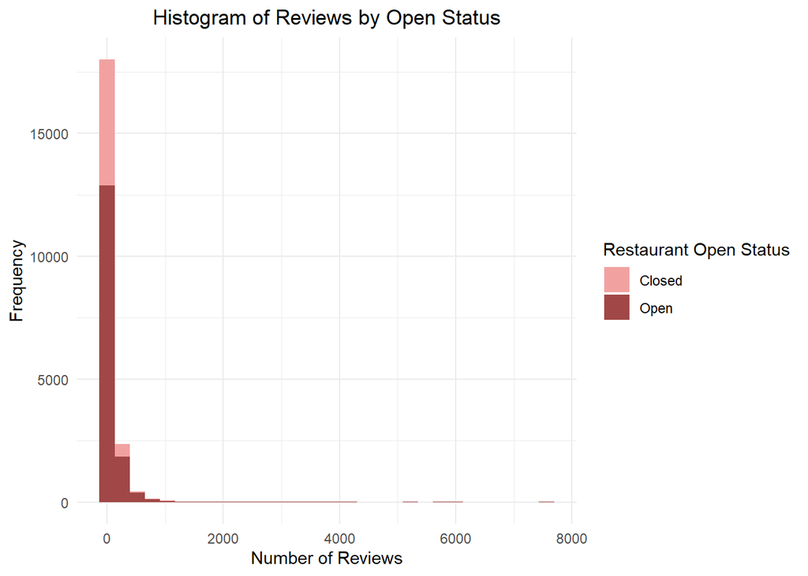

Graphing a histogram of review count stacked by open status, we notice that the distribution is generally right-skewed, with most values near 0 and a few outliers in the 1000s. Due to that, it is visually difficult to conclude if the two variables are related.

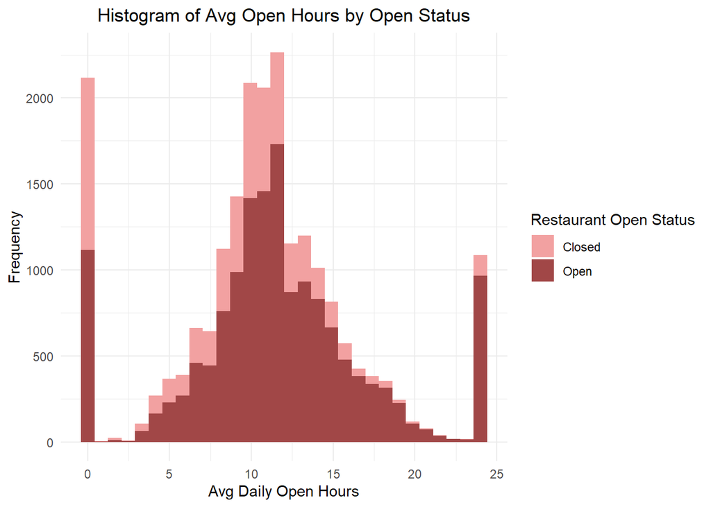

However, in terms of average daily open hours, among the restaurants that open more than 12 hours a day, there are significantly fewer restaurants that closed. We notice a number of businesses that have 0 open hours in the histogram. Those are the businesses that didn’t provide information on their weekly open hours, which could have meaningful implications as well.

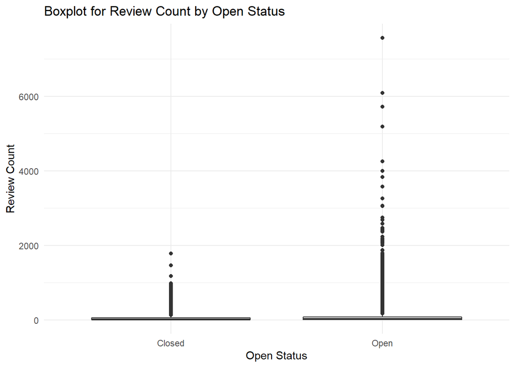

Here, we verify with the boxplot that we have numerous outliers for review count that may have to be handled prior to model construction.

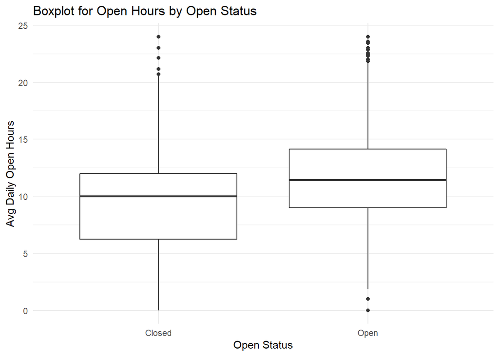

Here, the median average daily open hours is 1 hour more for restaurants that are still open versus those that closed. The interquartile range is also higher.

Next, we take a look at some of the relationships between categorical variables and ratings.

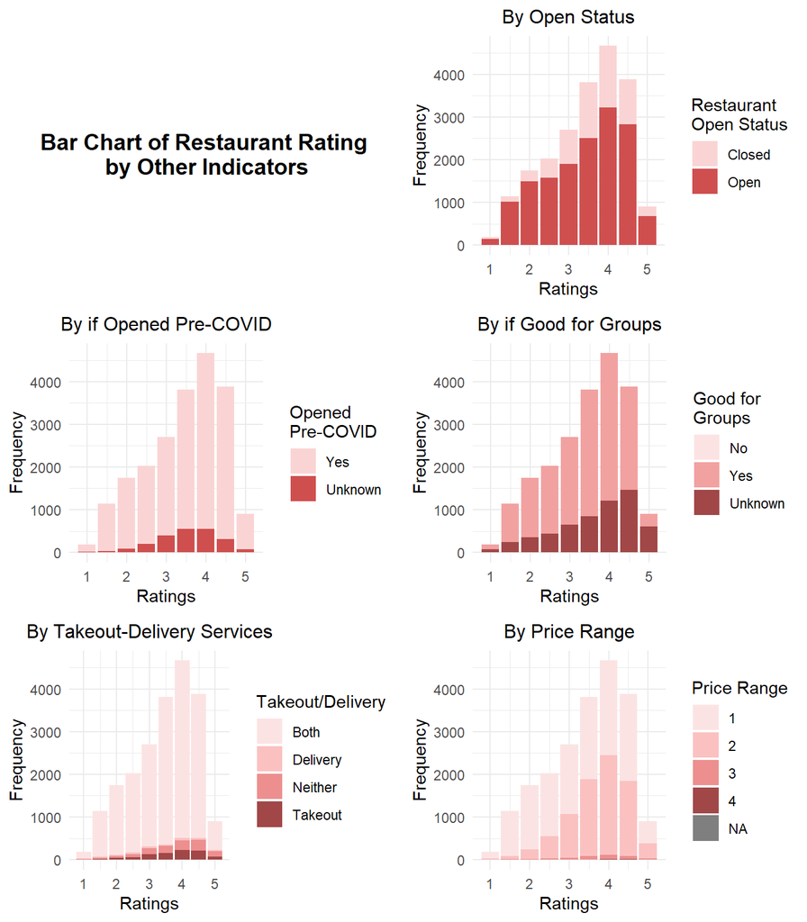

It is visible that a majority of the restaurants in our dataset have 4 stars. Looking at the distribution of ratings stacked by various indicator variables, the most significant relationship we see is that a high proportion of restaurants with rating 4 are good for groups and offer takeout/delivery. The association with open status, surprisingly, reveals that a higher proportion among restaurants with ratings < 3 are still open. Ratings and price range do not have as clear of an effect on each other.

For some time during the past two years, COVID has discouraged/forbidden indoor dining in various places. Hence, this feature could potentially have an impact on how reviewers perceive the business.

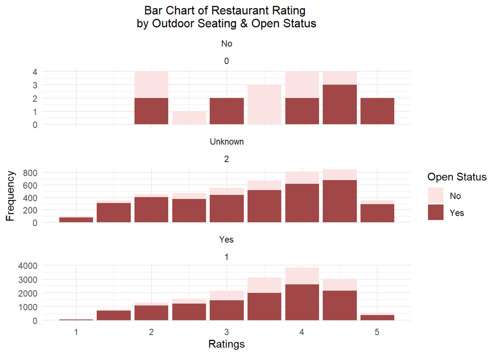

### Spatial Relationship: Rating & Location

[interactive chart not shown]

Mapping out the locations of these restaurants, we note that there is no data for restaurant businesses in Toronto, Montreal, and Madison metropolitan areas. However, there are additions from Baton Rouge (Louisiana), Nashville (Tennessee), Tampa (Florida), Indianapolis (Indiana), Boise (Idaho), and Santa Maria (California). There’s no visible trend for ratings in terms of location within each area with the current representation.

## Conclusion

Moving forward, the hypothesis I would like to test is: “Restaurants with more reviews and features that facilitate operation under COVID restrictions (outdoor seats, takeout/delivery, lower prices) generally have higher ratings and more positive reviews.”

From the preliminary results, I believe that a simple linear regression model might not be suitable or sufficient in representing the relationships between variables, which was why they were excluded from this report. First, some of the assumptions to linear regression, such as normality, are likely not satisfied given the skewness of certain variables. Moreover, it seems like some categorical variables have a non-linear relationship with ratings and possibly with review count, so it is worth looking into other model types (i.e. random forest) to account for those.

Another possible direction is to analyze the reviews more through NLP and compare the ones before and after the pandemic. Review content could be highly indicative of the restaurant’s performance and offer more insights related to COVID’s impact. From that, we may be able to extract other qualities that were not included in the `business` dataset.